# caret: Predictive Analysis Framework

Wednesday, April 16, 2014

## Welcome to the CRUG!

- Motivation
- Preprocessing
- Data Splitting
- Example
- Customization

## Motivation

## Another Predictive Analysis tool?

There are many R predictive analysis tool. Do we need another one?

Many choices, from k-Nearest Neighbor, Trees, Support Vector Machine, etc.

> **Data Science is more of an art than a science - Author unknown**

There's no free lunch, no single model/technique is capable of solving all the problems.

See http://cran.r-project.org/web/views/MachineLearning.html

## Problem with many approaches for the same techniques

| class | Package | Method |
| --- | --- | --- |
| lda | `MASS` | `predict(obj)` |
| rpart | `rpart` | `predict(obj, type='prob')` |
| glm | `stats` | `predict(obj, type='response')` |

## Why caret? (created by Max Kuhn):

- Unified interface for model tuning (instead of formula vs. matrices of predictors)
- Streamline the cross validation tasks
- Common interface for model prediction
- Provide helper methods
- Support parallel processing
- Currently there are ~150 models supported
  - http://caret.r-forge.r-project.org/modelList.html

## Preprocessing

## caret includes several functions to pre-process the predictor data

- Identify correlated predictors
- Centering and scaling
- etc ..

See http://caret.r-forge.r-project.org/preprocess.html

## Data Splitting

## Create data partition index

Creates stratified random splits

```r
library(caret)
train_idx <- createDataPartition(iris$Species,
                                  # 80% goes to training
                                  p = .8,
                                  list = FALSE,
                                  times = 1)
head(train_idx)
```

```
##      Resample1
## [1,]         1
## [2,]         2
## [3,]         3
## [4,]         4
## [5,]         5
## [6,]         6
```

## Split data between training and test

```r
iris_train <- iris[ train_idx,]
nrow(iris_train)
```

```
## [1] 120
```

```r
iris_test  <- iris[-train_idx,]
nrow(iris_test)
```

```
## [1] 30
```

## Split data for cross validation

```r
# create 10-fold cross validated stratified
cv_idx <- createFolds(iris_train$Species, 10)
str(cv_idx)
```

```
## List of 10
##  $ Fold01: int [1:12] 7 18 20 40 47 48 63 75 105 109 ...
##  $ Fold02: int [1:12] 3 5 28 31 42 56 62 73 83 98 ...
##  $ Fold03: int [1:12] 24 25 33 36 41 49 55 66 89 102 ...
##  $ Fold04: int [1:12] 4 9 11 32 45 53 64 79 84 93 ...
##  $ Fold05: int [1:12] 16 19 30 38 46 50 52 80 92 95 ...
##  $ Fold06: int [1:12] 2 27 29 34 44 58 60 77 81 88 ...
##  $ Fold07: int [1:12] 12 13 21 22 59 61 69 74 82 90 ...
##  $ Fold08: int [1:12] 6 23 37 39 51 57 67 76 87 100 ...
##  $ Fold09: int [1:12] 1 14 26 35 43 70 71 72 85 97 ...
##  $ Fold10: int [1:12] 8 10 15 17 54 65 68 78 86 96 ...
```

## Also supports time series model

It supports time series cross validations

See http://robjhyndman.com/hyndsight/crossvalidation/

```r
cv_ts <- createTimeSlices(1:12, 3, 1, fixedWindow = FALSE)
str(cv_ts[[1]])
```

```
## List of 9
##  $ Training1: int [1:3] 1 2 3
##  $ Training2: int [1:4] 1 2 3 4
##  $ Training3: int [1:5] 1 2 3 4 5
##  $ Training4: int [1:6] 1 2 3 4 5 6
##  $ Training5: int [1:7] 1 2 3 4 5 6 7
##  $ Training6: int [1:8] 1 2 3 4 5 6 7 8
##  $ Training7: int [1:9] 1 2 3 4 5 6 7 8 9
##  $ Training8: int [1:10] 1 2 3 4 5 6 7 8 9 10
##  $ Training9: int [1:11] 1 2 3 4 5 6 7 8 9 10 ...
```

## Example

## Data

Let's try to predict wine quality based on a set of covariates

```r
wine <- read.csv("./wineTrain.csv")
test_wine <- read.csv("./wineTest.csv", as.is = T)
str(wine)
```

```
## 'data.frame':    2961 obs. of  12 variables:
##  $ fixed.acidity       : num  7 8.1 7.2 8.1 8.6 7.9 6.6 8.3 6.6 6.3 ...
##  $ volatile.acidity    : num  0.27 0.28 0.23 0.22 0.23 0.18 0.16 0.42 0.17 0.48 ...
##  $ citric.acid         : num  0.36 0.4 0.32 0.43 0.4 0.37 0.4 0.62 0.38 0.04 ...
##  $ residual.sugar      : num  20.7 6.9 8.5 1.5 4.2 ...
##  $ chlorides           : num  0.045 0.05 0.058 0.044 0.035 0.04 0.044 0.04 0.032 0.046 ...
##  $ free.sulfur.dioxide : num  45 30 47 28 17 16 48 41 28 30 ...
##  $ total.sulfur.dioxide: num  170 97 186 129 109 75 143 172 112 99 ...
##  $ density             : num  1.001 0.995 0.996 0.994 0.995 ...
##  $ pH                  : num  3 3.26 3.19 3.22 3.14 3.18 3.54 2.98 3.25 3.24 ...
##  $ sulphates           : num  0.45 0.44 0.4 0.45 0.53 0.63 0.52 0.67 0.55 0.36 ...
##  $ alcohol             : num  8.8 10.1 9.9 11 9.7 10.8 12.4 9.7 11.4 9.6 ...
##  $ quality             : int  6 6 6 6 5 5 7 5 7 6 ...
```

```r
error.rate <- function(x, ref, digs = 3) round(mean(x != ref), digs)
```

For this presentation, we will focus on classification problem.

## Discretizing the response

The wine quality will be divided into 5 levels: Very Low, Low, Average, High and Very High

```r
wine$qual5 <- cut(wine$quality, c(3, 5:8, 10) - 0.5,
                 labels = c("Very Low", "Low", "Average", "High",
                            "Very High"))

test_wine$qual5 <- cut(test_wine$quality, c(3,5:8,10)-0.5,
                      labels=c("Very Low","Low","Average","High",
                               "Very High"))
```

## Normalized the data

```r
# scale the wine dataset for kNN
norm_wine <- as.data.frame(cbind(scale(wine[, c(-12,-13)]),
                                 qual5=wine[, 13]))

# similar scaling for test wine dataset using the same moments
# as the training set
norm_test_wine <- as.data.frame(
  cbind(scale(test_wine[, c(-12,-13)],
              center=apply(wine[, c(-12,-13)], 2, mean),
              scale=apply(wine[, c(-12, -13)], 2, sd)),
              qual5=test_wine[, 13]))
```

## For this presentation, we choose two of such technique

- kNN
  - In 1951, Berkeley statistician Evelyn Fix published (together with Joseph Hodges) a technical military-research report about a "Nonparametric Discriminant…"
  - Like resembles like.
  - Therefore, if you want to know a new data point's class, ask the points whose features it  
    resembles most!
- Random Forest (Tree classifier - Ensemble models)
  - Bootstrap the dataset, but each tree only uses randomly-sampled features. The feature sampling is without replacement. This reduces the correlation, and usually improves performance over ordinary "bagging."

## k Nearest Neighbor

## Cross Validating

```r
library(class)
# using 6-folds cv
wine_id <- createFolds(norm_wine$qual5, 6)
# tuning parameters odd k's only!
kays = seq(1, 33, 2)

knn.tune <- function(data, x, y, cvid, kays, ...) {
  cv_out <- matrix(NA,nrow=nrow(data),ncol=length(kays))
  for (b in 1:length(kays)) {
    for (a in names(cvid)) {
      ids <- cvid[[a]]
      cv_out[ids, b] <- knn(data[-ids, x], data[ids, x],
                            data[-ids, y], k=kays[b])
    }
  }
  cv_out
}
```

## Training

```r
train_knn <- knn.tune(norm_wine, c(1:11), c(12), wine_id, kays)

ercv1 <- apply(train_knn, 2, error.rate,
               ref=as.integer(norm_wine$qual5))

# best k
(best_k <- kays[which.min(ercv1)])
```

```
## [1] 33
```

## Predicting

```r
pred_knn <- knn(norm_wine[, -12], norm_test_wine[,-12], norm_wine[,12],
                best_k)
table(norm_test_wine$qual5, pred_knn)
```

```
##    pred_knn
##       1   2   3   4   5
##   1   0  24  18   1   0
##   2   0 166 130   6   0
##   3   0  95 329  43   0
##   4   0   7  94  57   0
##   5   0   0  19  11   0
```

```r
error.rate(pred_knn, norm_test_wine$qual5)
```

```
## [1] 0.448
```

## Random Forest

## Cross Validating

```r
library(randomForest)
library(doSNOW)
library(latticeExtra)

# Number of randomly sampled variable at each split
# Minimum size of terminal nodes
rf_grid <- expand.grid(.mtry=1:4,
                    .nodesize=1:10)
pwine <- table(wine$qual5) / length(wine$qual5)

# It will takes the average class 3 times the vote in order to win
(pinf <- -pwine*log(pwine))
```

```
##
##  Very Low       Low   Average      High Very High
##    0.1372    0.3601    0.3601    0.3082    0.1192
```

## CV continued

```r
cl <- makeCluster(4, type = "SOCK")
registerDoSNOW(cl)
infout<-foreach(a=1:dim(rf_grid)[1],.combine='rbind',
                .packages='randomForest') %dopar%
{
  tmp = randomForest(qual5~.
                     , data=wine[,-12], ntree=200
                     # the cutoff is based on information entrophy
                     , cutoff=pinf/sum(pinf), mtry=rf_grid$.mtry[a]
                     , nodesize=rf_grid$.nodesize[a])
  data.frame(thresh="Information"
             , m=rf_grid$.mtry[a]
             , nodesize=rf_grid$.nodesize[a]
             , err=error.rate(tmp$predicted,wine$qual5))
}

stopCluster(cl)
registerDoSEQ()
```

## Plot the CV result

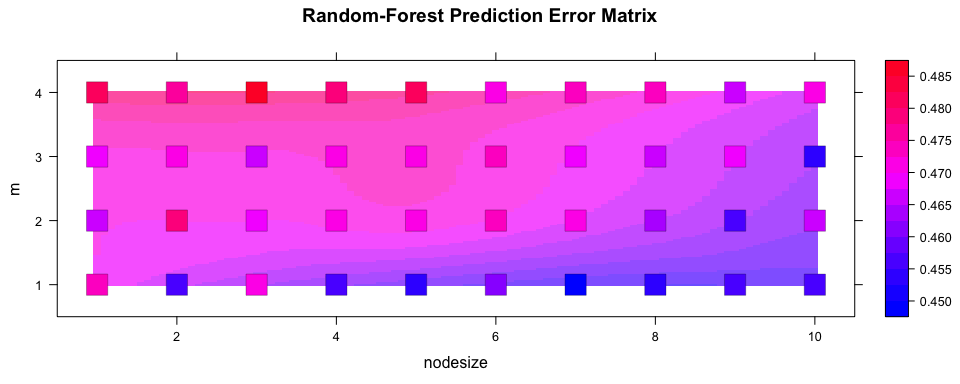

```r
levelplot(err~nodesize+m
          , data=infout
          , panel=panel.levelplot.points
          , cex=3,pch=22,col.regions=rainbow(31,start=2/3)
          , main="Random-Forest Prediction Error Matrix")+
layer_(panel.2dsmoother(...,col.regions=rainbow(31,start=2/3,alpha=0.7)))
```

## Training

```r
rf_train <- randomForest(qual5~.,
                         data=wine[,-12],
                         # tree to grow
                         ntree=500,
                         # cutoff for winning class
                         cutoff=round(pinf/sum(pinf),3),
                         # the higher the less detail
                         nodesize=10,
                         # number of randomly sampled var at each split
                         mtry=1)
```

## Plotting the result

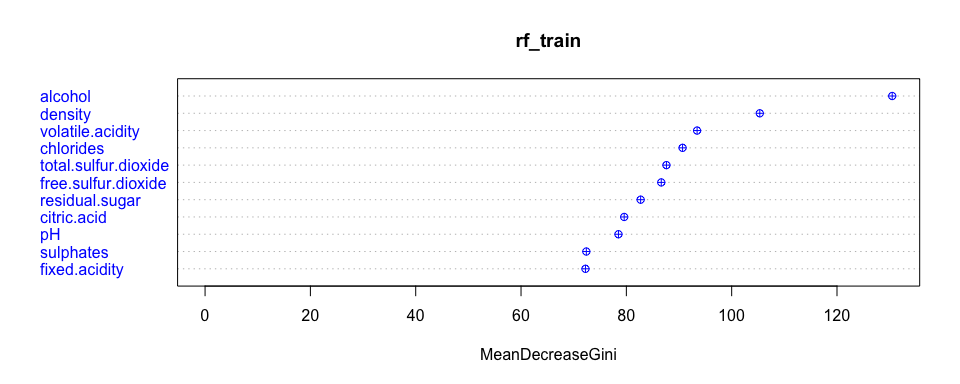

```r
# This plot shows that 1 parameter is good enough for each split since
# the predictive contribution is evenly distributed
varImpPlot(rf_train, pch=10, col=4)
```

## Plot - continued

```r
rf_train$confusion
```

```
##           Very Low Low Average High Very High class.error
## Very Low        29  58      42    1         0      0.7769
## Low             22 470     370   10         1      0.4616
## Average          8 230     968  113         2      0.2672
## High             3  11     345  162        10      0.6949
## Very High        0   0      58   45         3      0.9717
```

```r
error.rate(rf_train$predicted, wine$qual5)
```

```
## [1] 0.449
```

## Predicting

```r
rf_pred <- predict(rf_train, test_wine[,c(-12, -13)])
table(test_wine$qual5, rf_pred)
```

```
##            rf_pred
##             Very Low Low Average High Very High
##   Very Low        10  19      14    0         0
##   Low              4 166     129    3         0
##   Average          3  72     347   45         0
##   High             2   3      98   55         0
##   Very High        0   0      18   10         2
```

```r
error.rate(rf_pred, test_wine$qual5)
```

```
## [1] 0.42
```

## kNN with caret

## Training and Cross Validating

```r
library(doMC)
library(parallel)
registerDoMC(detectCores()-2)

# setup 6-fold repeated CV
ctrl <- trainControl(method='cv',
                     number=6)

# to ensure the two models can be compared
set.seed(1234)

knn_tune <- train(wine[,-c(12,13)],
                 wine$qual5,
                 method = "knn",
                 # Center and scaling will occur for new predictions too
                 preProc = c("center", "scale"),
                 tuneGrid = data.frame(.k = kays),
                 trControl = ctrl)
```

## Plot result

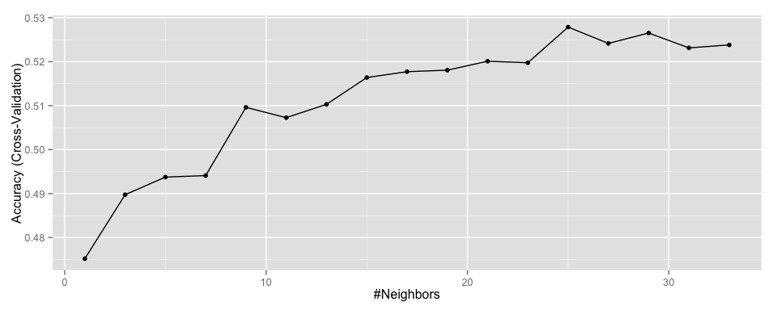

```r
library(ggplot2)
# default metric for classification is 'accuracy'
# dev.off()
ggplot(knn_tune) + theme(legend.position = "top")
```

## Predicting

```r
knn_pred <- predict(knn_tune, newdata = test_wine[,-c(12,13)])

table(test_wine$qual5, knn_pred)
```

```
##            knn_pred
##             Very Low Low Average High Very High
##   Very Low         0  27      15    1         0
##   Low              0 163     133    6         0
##   Average          0  97     328   42         0
##   High             0   6      89   63         0
##   Very High        0   1      17   12         0
```

```r
error.rate(knn_pred, test_wine$qual5)
```

```
## [1] 0.446
```

## RandomForest with caret

## Training and Cross Validating

```r
# the version doesn't support nodesize
rf_tune <- train(wine[,-c(12,13)],
                 wine$qual5,
                 method = "rf",
                 tuneGrid = expand.grid(.mtry=1:4),
                 trControl = ctrl)
```

## Plot result

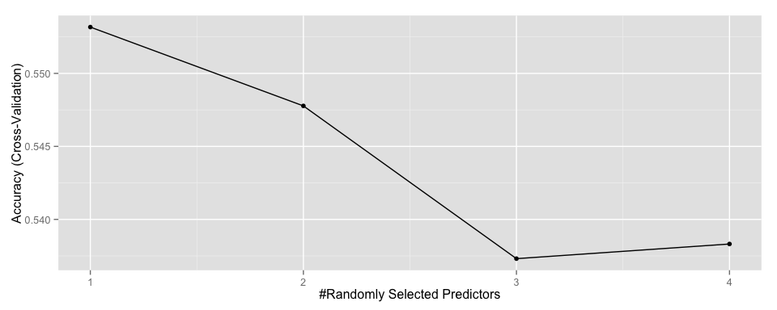

```r
ggplot(rf_tune) + theme(legend.position = "top")
```

## Plot result - continued

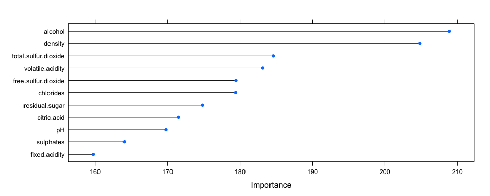

```r
plot(varImp(rf_tune, scale = F))
```

## Predicting

```r
rf_pred <- predict(rf_tune, newdata = test_wine[,-c(12,13)])
table(test_wine$qual5, rf_pred)
```

```
##            rf_pred
##             Very Low Low Average High Very High
##   Very Low         1  23      19    0         0
##   Low              1 175     124    2         0
##   Average          1  73     359   34         0
##   High             0   4     103   51         0
##   Very High        0   1      17    9         3
```

```r
error.rate(rf_pred, test_wine$qual5)
```

```
## [1] 0.411
```

## Comparing the two models using caret

```r
resamps <- resamples(list(KNN = knn_tune,
                          RF = rf_tune))
difValues <- diff(resamps)
```

## Is the significant different?

```r
summary(difValues)
```

```
##
## Call:
## summary.diff.resamples(object = difValues)
##
## p-value adjustment: bonferroni
## Upper diagonal: estimates of the difference
## Lower diagonal: p-value for H0: difference = 0
##
## Accuracy
##     KNN   RF
## KNN       -0.0253
## RF  0.135
##
## Kappa
##     KNN   RF
## KNN       -0.0356
## RF  0.224
```

## Want to do more customization?

## Can't find your model of choice in the caret library?

caret will allow you to build your own model to its framework.

See http://caret.r-forge.r-project.org/custom_models.html

## Let's extend the Random Forest support

```r
lpRF <- getModelInfo(model = "rf", regex = FALSE)[[1]]
lpRF$parameters <- data.frame(parameter = c("mtry", "nodesize"),
                              class = rep("numeric", 2),
                              label = c("mtry", "nodesize"))

lpRF$fit <- function(x, y, wts, param, lev, last, weights, classProbs, ...) {
  randomForest(x = as.matrix(x), y = y,
               ntree=500,
               nodesize=param$nodesize,
               mtry=param$mtry,...)
}
```

## Tune the new model

```r
new_rf_tune <- train.default(wine[,-c(12,13)],
                 wine$qual5,
                 method=lpRF,
                 # optional, otherwise the default is used
                 tuneGrid=rf_grid,
                 trControl=ctrl)
```

## Tuning result

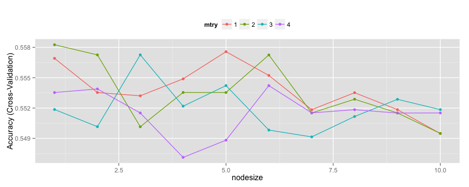

```r
ggplot(new_rf_tune) + theme(legend.position = "top")
```

## Predicting with new model

```r
new_rf_pred <- predict(new_rf_tune, newdata = test_wine[,-c(12,13)])
table(test_wine$qual5, new_rf_pred)
```

```
##            new_rf_pred
##             Very Low Low Average High Very High
##   Very Low         3  22      18    0         0
##   Low              1 174     124    3         0
##   Average          0  80     346   41         0
##   High             0   5      99   54         0
##   Very High        0   1      17    9         3
```

```r
error.rate(new_rf_pred, test_wine$qual5)
```

```
## [1] 0.42
```

## Want to create more parsimonous model?

caret provides 'rfe' and 'rfeiter' to allow for feature elimination.

See http://caret.r-forge.r-project.org/featureselection.html

## References:

http://caret.r-forge.r-project.org/index.html

http://www.stat.berkeley.edu/~breiman/RandomForests/

http://www.scholarpedia.org/article/K-nearest_neighbor

http://statweb.stanford.edu/~tibs/ElemStatLearn/